# block2Assignment3

2025-11-19

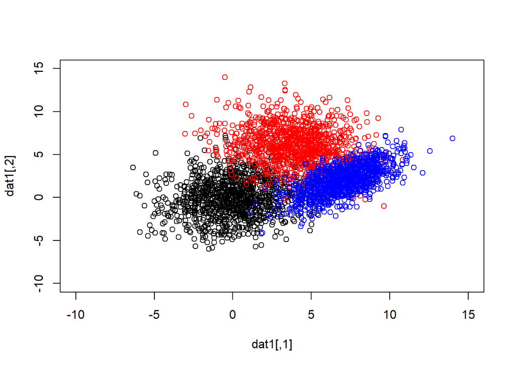

```
## Task 1: Test Error (Single GMM/QDA Model) = 0.091
```

```
## Task 2: Test Error (Bagging with B = 10 ) = 0.09033333
```

**Comments** Bagging (bootstrap aggregation) reduces variance by majority voting or averaging many different models. But it only helps much when the base learners are high-variance (their predictions change a lot with different training samples). Bagging improves models that change a lot when the training data changes (high variance), like:

- decision trees
- neural networks
- nearest neighbors

Possible reasons bagging gave almost no improvement here:

- Low variance base model: The generative/QDA-style classifier (Gaussian per class) is fairly stable — different bootstrap samples produce very similar parameter estimates, so the B models are almost the same. Majority voting with similar models doesn’t change much. Even when we bootstrap the dataset, each resample gives almost the same:
  - mean
  - covariance
  - prior

So each of the 10 models ends up nearly identical.When all models are similar, bagging gives almost no improvement.

- Strong correlation between base learners: With a small training set or when classes are well separated, bootstrap samples contain mostly the same information. The base models are highly correlated → majority vote gives little gain.